# Machine Learning Project.

# Abstract.

With the current technological advancement, there are applications that collect large amounts of data on personal activity.e.g *Nike+FuelBand*. This data can be qunatified and measured for health improvement by finding patterns on the behaviour.

The project is based on 6 participants. The purpose for the project is to predict how well someone does the workout based on the respective maneuvers. The data collected is from the accelorometers on the belt, forearm, arm, and dumbell. The variable *'classe'* was used as the response variable with 5 classes; *A* represents working out exactly according to specification (the correct way), *B* represents throwing the elbows to the front (incorrect), *C* represents lifting the dumbell only halfway (incorrect), *D* represents lowering the dumbell only haflway (incorrect) and *E* represents throwing the hips infront. Measurments were taken to see how participants moved in the x-y-z plane for each different maneuvers, which is what will be used to build a **prediction function**. The data was collected by a research development team from [GroupwareLESS](http://groupware.les.inf.puc-rio.br/har).

## Loading the packages.

```r
library(caret)
library(xgboost)
library(Matrix)
```

# Downloading the data

The training data has 19622 observations with 160 variables, while test data has 20 observations with 160 variables.

```r
trainB<-read.csv("pmr-training.csv", na.strings = c("NA",""))
test<-read.csv("pml-testing.csv", na.strings = c("NA",""))
```

## Data Preview

```r
str(trainB)
```

```
## 'data.frame':    19622 obs. of  160 variables:
##  $ X                       : int  1 2 3 4 5 6 7 8 9 10 ...
##  $ user_name               : Factor w/ 6 levels "adelmo","carlitos",..: 2 2 2 2 2 2 2 2 2 2 ...
##  $ raw_timestamp_part_1    : int  1323084231 1323084231 1323084231 1323084232 1323084232 1323084232 1323084232 1323084232 1323084232 1323084232 ...
##  $ raw_timestamp_part_2    : int  788290 808298 820366 120339 196328 304277 368296 440390 484323 484434 ...
##  $ cvtd_timestamp          : Factor w/ 20 levels "02/12/2011 13:32",..: 9 9 9 9 9 9 9 9 9 9 ...
##  $ new_window              : Factor w/ 2 levels "no","yes": 1 1 1 1 1 1 1 1 1 1 ...
##  $ num_window              : int  11 11 11 12 12 12 12 12 12 12 ...
##  $ roll_belt               : num  1.41 1.41 1.42 1.48 1.48 1.45 1.42 1.42 1.43 1.45 ...
##  $ pitch_belt              : num  8.07 8.07 8.07 8.05 8.07 8.06 8.09 8.13 8.16 8.17 ...
##  $ yaw_belt                : num  -94.4 -94.4 -94.4 -94.4 -94.4 -94.4 -94.4 -94.4 -94.4 -94.4 ...
##  $ total_accel_belt        : int  3 3 3 3 3 3 3 3 3 3 ...
##  $ kurtosis_roll_belt      : Factor w/ 396 levels "-0.016850","-0.021024",..: NA NA NA NA NA NA NA NA NA NA ...
##  $ kurtosis_picth_belt     : Factor w/ 316 levels "-0.021887","-0.060755",..: NA NA NA NA NA NA NA NA NA NA ...
##  $ kurtosis_yaw_belt       : Factor w/ 1 level "#DIV/0!": NA NA NA NA NA NA NA NA NA NA ...
```

[output cut: 86 more lines]

# Cleaning the data.

Function for pruning features and eliminating missing variables.

```r
preprocess<-function(data){
  NAs<-sapply(data, function(x) sum(is.na(x)))
  data1<-data[,which(NAs==0)]
  #Considering variables that are viable for the analysis.
  validcol<-grepl("arm|dumbell|forearm|belt|classe", names(data1))
  data2<-data1[,validcol]

  return(data2)

}
#Generating respective new data sest from the preprocess function.
train<-preprocess(trainB)
test<-preprocess(test)
```

New dataset summary.

```r
str(train)
```

```
## 'data.frame':    19622 obs. of  40 variables:
##  $ roll_belt          : num  1.41 1.41 1.42 1.48 1.48 1.45 1.42 1.42 1.43 1.45 ...
##  $ pitch_belt         : num  8.07 8.07 8.07 8.05 8.07 8.06 8.09 8.13 8.16 8.17 ...
##  $ yaw_belt           : num  -94.4 -94.4 -94.4 -94.4 -94.4 -94.4 -94.4 -94.4 -94.4 -94.4 ...
##  $ total_accel_belt   : int  3 3 3 3 3 3 3 3 3 3 ...
##  $ gyros_belt_x       : num  0 0.02 0 0.02 0.02 0.02 0.02 0.02 0.02 0.03 ...
##  $ gyros_belt_y       : num  0 0 0 0 0.02 0 0 0 0 0 ...
##  $ gyros_belt_z       : num  -0.02 -0.02 -0.02 -0.03 -0.02 -0.02 -0.02 -0.02 -0.02 0 ...
##  $ accel_belt_x       : int  -21 -22 -20 -22 -21 -21 -22 -22 -20 -21 ...
##  $ accel_belt_y       : int  4 4 5 3 2 4 3 4 2 4 ...
##  $ accel_belt_z       : int  22 22 23 21 24 21 21 21 24 22 ...
##  $ magnet_belt_x      : int  -3 -7 -2 -6 -6 0 -4 -2 1 -3 ...
##  $ magnet_belt_y      : int  599 608 600 604 600 603 599 603 602 609 ...
##  $ magnet_belt_z      : int  -313 -311 -305 -310 -302 -312 -311 -313 -312 -308 ...
##  $ roll_arm           : num  -128 -128 -128 -128 -128 -128 -128 -128 -128 -128 ...
```

[output cut: 26 more lines]

Creating an output that shows respective group class for activity quality under the dependent variable *classe*.

```r
output<-train[,"classe"]
levels(output)
## [1] "A" "B" "C" "D" "E"
numclass<-5
```

Removing *output* from the training data.

```r
train$classe<-NULL
```

Checking for variation within the variables.

```r
myzerovar<-nearZeroVar(train, saveMetrics = TRUE)
print(myzerovar)
```

```
##                     freqRatio percentUnique zeroVar   nzv
## roll_belt            1.101904     6.7781062   FALSE FALSE
## pitch_belt           1.036082     9.3772296   FALSE FALSE
## yaw_belt             1.058480     9.9734991   FALSE FALSE
## total_accel_belt     1.063160     0.1477933   FALSE FALSE
## gyros_belt_x         1.058651     0.7134849   FALSE FALSE
## gyros_belt_y         1.144000     0.3516461   FALSE FALSE
## gyros_belt_z         1.066214     0.8612782   FALSE FALSE
## accel_belt_x         1.055412     0.8357966   FALSE FALSE
## accel_belt_y         1.113725     0.7287738   FALSE FALSE
## accel_belt_z         1.078767     1.5237998   FALSE FALSE
## magnet_belt_x        1.090141     1.6664968   FALSE FALSE
## magnet_belt_y        1.099688     1.5187035   FALSE FALSE
## magnet_belt_z        1.006369     2.3290184   FALSE FALSE
## roll_arm            52.338462    13.5256345   FALSE FALSE
## pitch_arm           87.256410    15.7323412   FALSE FALSE
## yaw_arm             33.029126    14.6570176   FALSE FALSE
## total_accel_arm      1.024526     0.3363572   FALSE FALSE
## gyros_arm_x          1.015504     3.2769341   FALSE FALSE
## gyros_arm_y          1.454369     1.9162165   FALSE FALSE
## gyros_arm_z          1.110687     1.2638875   FALSE FALSE
## accel_arm_x          1.017341     3.9598410   FALSE FALSE
## accel_arm_y          1.140187     2.7367241   FALSE FALSE
## accel_arm_z          1.128000     4.0362858   FALSE FALSE
## magnet_arm_x         1.000000     6.8239731   FALSE FALSE
## magnet_arm_y         1.056818     4.4439914   FALSE FALSE
## magnet_arm_z         1.036364     6.4468454   FALSE FALSE
## roll_forearm        11.589286    11.0895933   FALSE FALSE
## pitch_forearm       65.983051    14.8557741   FALSE FALSE
## yaw_forearm         15.322835    10.1467740   FALSE FALSE
## total_accel_forearm  1.128928     0.3567424   FALSE FALSE
## gyros_forearm_x      1.059273     1.5187035   FALSE FALSE
## gyros_forearm_y      1.036554     3.7763735   FALSE FALSE
## gyros_forearm_z      1.122917     1.5645704   FALSE FALSE
## accel_forearm_x      1.126437     4.0464784   FALSE FALSE
## accel_forearm_y      1.059406     5.1116094   FALSE FALSE
## accel_forearm_z      1.006250     2.9558659   FALSE FALSE
## magnet_forearm_x     1.012346     7.7667924   FALSE FALSE
## magnet_forearm_y     1.246914     9.5403119   FALSE FALSE
## magnet_forearm_z     1.000000     8.5771073   FALSE FALSE
```

# Building Machine Learning Model.

The machine learning model for prediciting activity quality *classe* from the activity monitor *features* will be modeled using the **XGBoost** extreme gradient boosting package.

XGBoost only supports numeric matrix data, hence, the training, testing and output data is converted into matrix. The first step of the modeling process will be to perform a cross-validation so as to determine the accuracy of the data and model. This will be done using the *xgb.cv* function.

```r
#converting to numeric.
train2<-data.frame(lapply(train, as.numeric))
test2<-data.frame(lapply(test, as.numeric))

#converting to matrix
trainMatrix<-as.matrix(train2)
testMatrix<-as.matrix(test2)

#xgboost takes multi-labels in [0, numofClass]
y<-as.matrix(as.integer(output)-1)

#Converting train and test data matrix into xgb matrix.
xgTrain<-xgb.DMatrix(trainMatrix, label=y)
xgTest<-xgb.DMatrix(testMatrix)
```

#### Setting the parameters for;

- Crosss validation and training.
- Multiclass classification objective, as the gradient boosting’s learning function.
- Evaluation metric *merror* for evaluating multiclass error rate.
- Number of iterations *nrounds* and *num_rounds*.

```r
params<-list("objective" = "multi:softprob",    # multiclass classification
     "num_class"=numclass, #number of classed
     "nthread" = 5,   # number of threads to be used
     "max_depth" = 16,    # maximum depth of tree
     "eta" = 0.3,    # step size shrinkage
     "gamma" = 0,    # minimum loss reduction
     "subsample" = .9,    # part of data instances to grow tree
     "colsample_bytree" = 1,  # subsample ratio of columns when constructing each tree
     "eval_metric"= 'merror',
     "min_child_weight" = 8)
#To be used in final prediction function modeling.
num_rounds<-150
```

For a good classification prediction, the expected error rate should be less than 1%. I did a cross validation using 4-fold cross validation with 150 rounds to reach the expected error rate.

```r
set.seed(1027)
bst.cv<-xgb.cv(params = params, data=trainMatrix, label = y, nrounds = 150,
               nfold=4, prediction=TRUE, verbose=0)
tail(bst.cv$dt)
```

```
##    train.merror.mean train.merror.std test.merror.mean test.merror.std
## 1:                 0                0         0.005402        0.000857
## 2:                 0                0         0.005504        0.000762
## 3:                 0                0         0.005555        0.000854
## 4:                 0                0         0.005504        0.000926
## 5:                 0                0         0.005453        0.000947
## 6:                 0                0         0.005453        0.000769
```

From the cross-validation on the model iteration, the best minimum error is as shown below and that was the optimal model that would be used for further prediction in relation to minimum expected error as shown that is less than 1%.

```r
#The iteration of minimum error
merror.min<-which.min(bst.cv$dt[,test.merror.mean])
print(merror.min)
```

```
## [1] 129
```

```r
#Minimu error for the model.
bst.cv$dt[merror.min,]
```

```
##    train.merror.mean train.merror.std test.merror.mean test.merror.std
## 1:                 0                0         0.005351        0.000732
```

### ConfusionMatrix.

The true predicted values are shown diagonaly from the top left corner of the matrix for each class.

```r
mypred<-matrix(bst.cv$pred, nrow = length(bst.cv$pred)/numclass, ncol = numclass)
mypred<-max.col(mypred,"last")
confusionMatrix(factor(y+1), factor(mypred))
```

```
## Confusion Matrix and Statistics
##
##           Reference
## Prediction    1    2    3    4    5
##          1 5566    8    6    0    0
##          2    9 3775   12    0    1
##          3    0   18 3385   18    1
##          4    0    0   17 3194    5
##          5    0    1    1   10 3595
##
## Overall Statistics
##
##                Accuracy : 0.9945
##                  95% CI : (0.9934, 0.9955)
##     No Information Rate : 0.2841
##     P-Value [Acc > NIR] : < 2.2e-16
##
##                   Kappa : 0.9931
##  Mcnemar's Test P-Value : NA
##
## Statistics by Class:
##
##                      Class: 1 Class: 2 Class: 3 Class: 4 Class: 5
## Sensitivity            0.9984   0.9929   0.9895   0.9913   0.9981
## Specificity            0.9990   0.9986   0.9977   0.9987   0.9993
## Pos Pred Value         0.9975   0.9942   0.9892   0.9932   0.9967
## Neg Pred Value         0.9994   0.9983   0.9978   0.9983   0.9996
## Prevalence             0.2841   0.1938   0.1743   0.1642   0.1836
## Detection Rate         0.2837   0.1924   0.1725   0.1628   0.1832
## Detection Prevalence   0.2844   0.1935   0.1744   0.1639   0.1838
## Balanced Accuracy      0.9987   0.9958   0.9936   0.9950   0.9987
```

From the above indication, the model is accurate and hence good for predicting the test data. We can then proceed further to build a machine learning algortihm that will train the data and build a prediction function that will predict the test data set.

### Model Training

```r
xgbmod<-xgb.train(xgTrain, params = params, num_rounds,verbose = 0)
```

### Predicing the test data set.

```r
xgbpred<-predict(xgbmod,xgTest)
head(xgbpred)
```

```
## [1] 0.0002907780 0.9983167648 0.0010889568 0.0001084541 0.0001951229
## [6] 0.9992092848
```

The predicted values have to be converted back to the actual 5 categorical classes, i.e, (A,B,C,D,E) as follows.

```r
mypred1<-matrix(xgbpred, nrow=numclass, ncol = length(xgbpred)/numclass)
mypred1<-t(mypred1)
mypred1<-max.col(mypred1,"last")
final<-toupper(letters[mypred1])
print(final)
```

```
##  [1] "B" "A" "B" "A" "A" "E" "D" "B" "A" "A" "B" "C" "B" "A" "E" "E" "A"
## [18] "B" "B" "B"
```

# Visualizing Feature Importance.

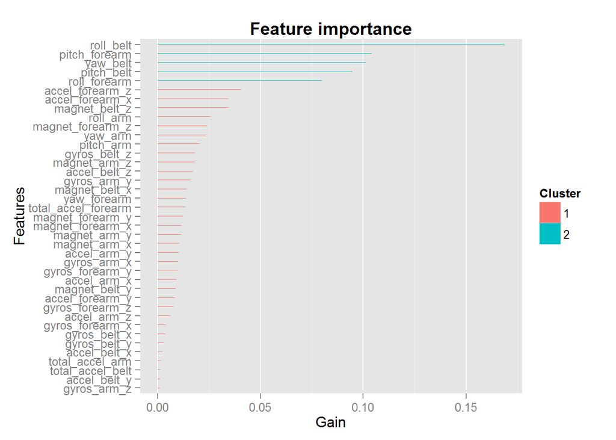

```r
model<-xgb.dump(xgbmod, with.stats = TRUE)
mynames<-dimnames(trainMatrix)[[2]]
rank<-xgb.importance(mynames, model=xgbmod)
#Plot
xgbplot<-xgb.plot.importance(rank)
print(xgbplot)
```

> *The graph clearly ranks the features in relation to their siginificance to the response variable(*classe*).Variables with lower significance to the response can be removed for a more robust predictive model.*